# Matt Part

# Our Data

By just looking at the data multiple quesitons can be formed, is crime going down, are certain areas more prone to crime than others?

I will try to answer these three questions:

- What is the most dangerous area in Ireland
- Historically, how did the crime in this area change?
- How do the differnet crimes correlate to eachother, does more of one crime mean more of another?

## Method

To answer these questions I will seperate the data into the 4 provinces of Ireland: Leinster, Munster, Ulster and Connacht on which I will conduct various statistics.

The location of the Garda Station is a nominal variable, while all the crime figures are intervals.

# Statistics

Lets take a closer look at our data, first lets get the average number of crimes in each Province in the years between 2004 and 2016:

Crimes Per Province 2004 - 2016

|  | Average Crimes Per Year |
| --- | --- |
| Leinster | 148451.77 |
| Munster | 58264.15 |
| Connacht | 20609.54 |
| Ulster | 11631.62 |

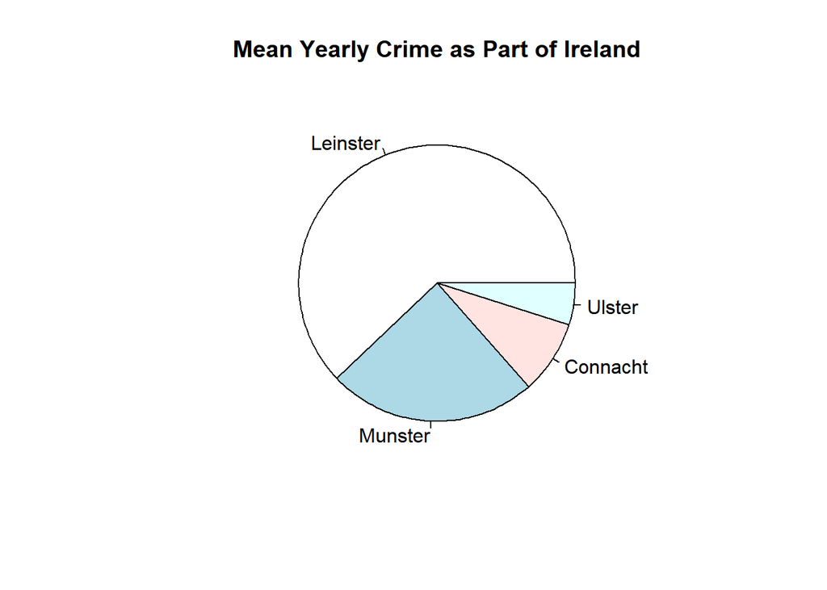

From this graph we can understand that over 50% of crimes commited yearly happen in Leinster, this could be due to the population disrecpency between the provinces, let’s see what happens when we normalize the data a bit, using population data from the 2016 census, which is limiting us to only looking at 2016 crime rates.

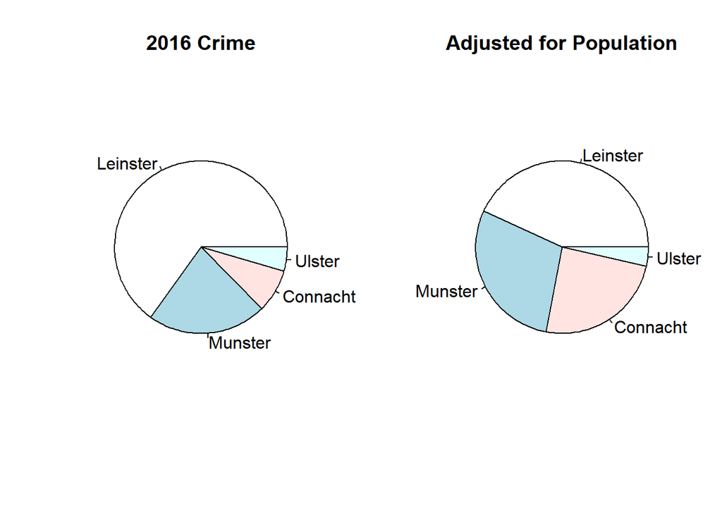

This tells us a bit of a different story, after adjusting for population we can see that Crime per Person in Connacht is a lot higher than in Ulster, while in the unadjusted chart it looked very similar.

From this we can infer that Ulster is the safest province in Ireland, while Leinster and Munster are the most dangerous.

## Closer look at Leinster

Let us take a closer look at Leinster, to see how Leinster changed over the years, and which parts are the most dangerous. We’re first going to take a look at the Distribution of Crimes between different Garda Divisions in Leinster

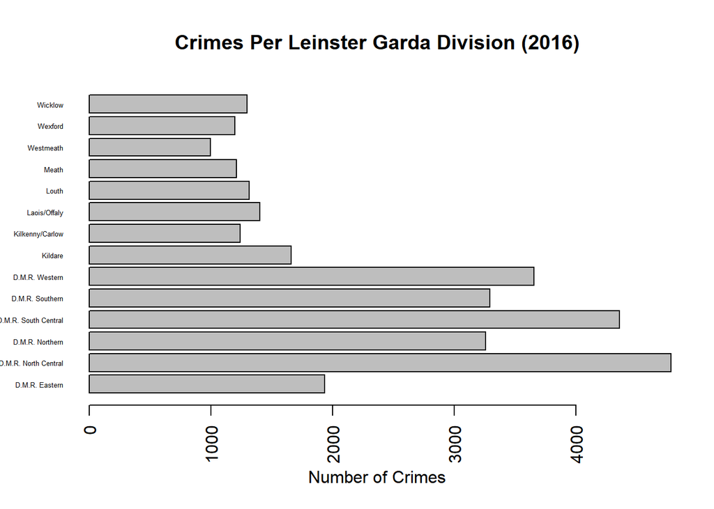

From this graph we can clearly see that Dublin North Central had the most crimes in Leinster in 2016, totalling up at 4783! Looking closer at Dublin North Central we can see that it covers the Garda Stations located at Bridewell Dublin, Fitzgibbon Street, Mountjoy, Store Street, these Garda Stations reported the most crime in 2016.

### Leinster Over The Years

If we take a look at the sum of crimes in Leinster over the years

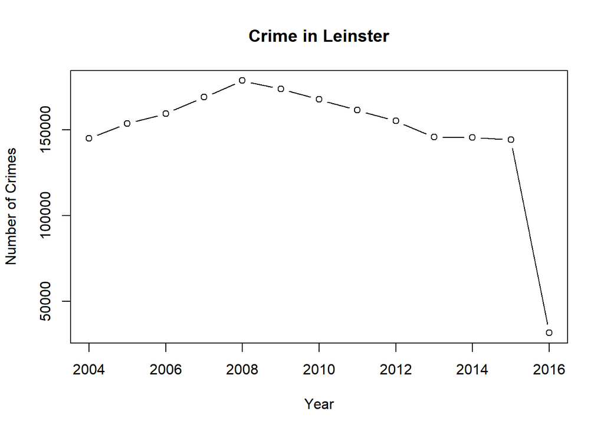

we see that the crime in Leinster peaked in 2008, and slowly went down from there, until it hit the lowest value of 31616 in 2016, a very sharp decrease in reported crime!

# Deep into Crime

Here we’re going to examine how differnet crimes relate to eachother, we’re going to use Pearsons Correlation Co-Efficient to examine linear relationships between the data.

Lets take a look at a few scatterplots using data from 2016

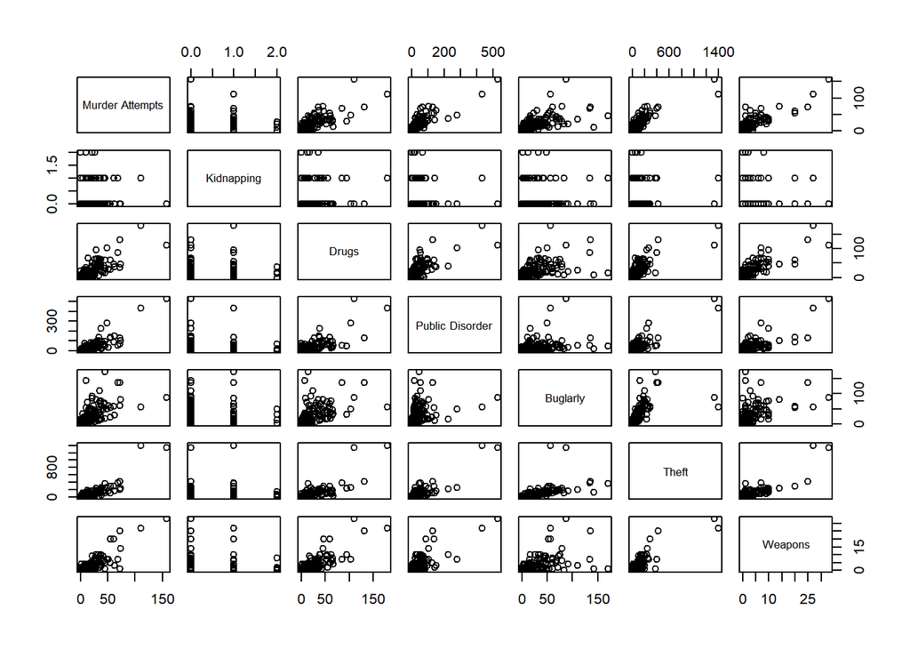

From looking at the scatterplots we can see that some of our chosen crimes seem to have a correlation with eachother, lets take a closer look at some of them

## Drugs and Murder

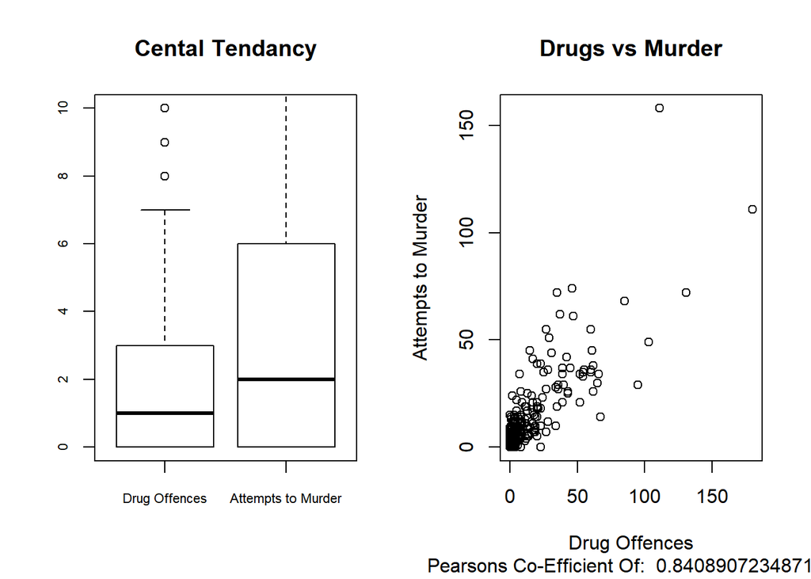

Judging by the graphs and the Perasons co-efficient, there is a strong positive correlation between the two, meaning that attempts to murder can be linked to the use of drugs.

## Burglary and Theft

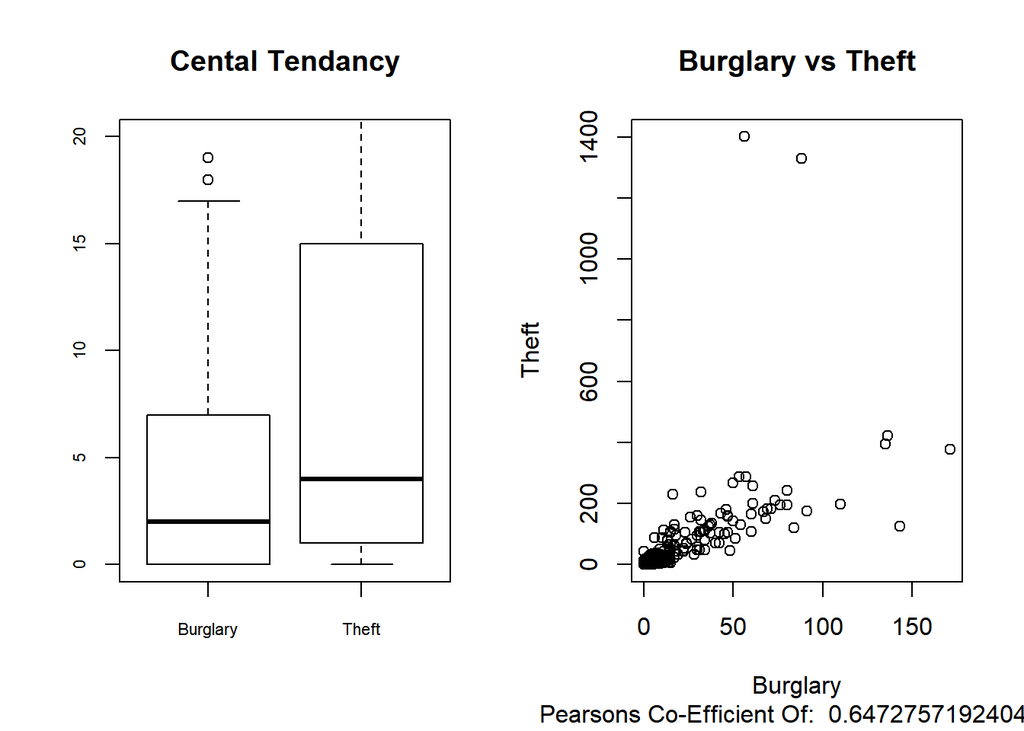

Looking at Burglary vs Theft, the correlation is weaker than that of Drugs and Murder, there might be some correlation between the two but it is not certian.